# Exam 3 - Noah Baculi ME224 Fall 2019

## Imports

```python
import math, functools, operator, collections, timeit
import folium  # (pip install folium)
from folium.plugins import HeatMap
from math import sin, cos, sqrt, atan2, radians
import pandas as pd
import matplotlib.pyplot as plt
import numpy as np
%matplotlib inline

start_time_tot = timeit.default_timer()
```

## Question 1

```python
year = 2008  # year of data desired
```

```python
df_flights = pd.read_csv(str(year) + '.csv.bz2')  # read data into df
# df_flights = df_flights[:20]  # comment out for unshortened data
df_flights
```

|  | Year | Month | DayofMonth | DayOfWeek | DepTime | CRSDepTime | ArrTime | CRSArrTime | UniqueCarrier | FlightNum | ... | TaxiIn | TaxiOut | Cancelled | CancellationCode | Diverted | CarrierDelay | WeatherDelay | NASDelay | SecurityDelay | LateAircraftDelay |
| --- | --- | --- | --- | --- | --- | --- | --- | --- | --- | --- | --- | --- | --- | --- | --- | --- | --- | --- | --- | --- | --- |
| 0 | 2008 | 1 | 3 | 4 | 2003.0 | 1955 | 2211.0 | 2225 | WN | 335 | ... | 4.0 | 8.0 | 0 | NaN | 0 | NaN | NaN | NaN | NaN | NaN |
| 1 | 2008 | 1 | 3 | 4 | 754.0 | 735 | 1002.0 | 1000 | WN | 3231 | ... | 5.0 | 10.0 | 0 | NaN | 0 | NaN | NaN | NaN | NaN | NaN |
| 2 | 2008 | 1 | 3 | 4 | 628.0 | 620 | 804.0 | 750 | WN | 448 | ... | 3.0 | 17.0 | 0 | NaN | 0 | NaN | NaN | NaN | NaN | NaN |
| 3 | 2008 | 1 | 3 | 4 | 926.0 | 930 | 1054.0 | 1100 | WN | 1746 | ... | 3.0 | 7.0 | 0 | NaN | 0 | NaN | NaN | NaN | NaN | NaN |
| 4 | 2008 | 1 | 3 | 4 | 1829.0 | 1755 | 1959.0 | 1925 | WN | 3920 | ... | 3.0 | 10.0 | 0 | NaN | 0 | 2.0 | 0.0 | 0.0 | 0.0 | 32.0 |
| 5 | 2008 | 1 | 3 | 4 | 1940.0 | 1915 | 2121.0 | 2110 | WN | 378 | ... | 4.0 | 10.0 | 0 | NaN | 0 | NaN | NaN | NaN | NaN | NaN |
| 6 | 2008 | 1 | 3 | 4 | 1937.0 | 1830 | 2037.0 | 1940 | WN | 509 | ... | 3.0 | 7.0 | 0 | NaN | 0 | 10.0 | 0.0 | 0.0 | 0.0 | 47.0 |
| 7 | 2008 | 1 | 3 | 4 | 1039.0 | 1040 | 1132.0 | 1150 | WN | 535 | ... | 7.0 | 7.0 | 0 | NaN | 0 | NaN | NaN | NaN | NaN | NaN |
| 8 | 2008 | 1 | 3 | 4 | 617.0 | 615 | 652.0 | 650 | WN | 11 | ... | 6.0 | 19.0 | 0 | NaN | 0 | NaN | NaN | NaN | NaN | NaN |
| 9 | 2008 | 1 | 3 | 4 | 1620.0 | 1620 | 1639.0 | 1655 | WN | 810 | ... | 3.0 | 6.0 | 0 | NaN | 0 | NaN | NaN | NaN | NaN | NaN |
| 10 | 2008 | 1 | 3 | 4 | 706.0 | 700 | 916.0 | 915 | WN | 100 | ... | 5.0 | 19.0 | 0 | NaN | 0 | NaN | NaN | NaN | NaN | NaN |
| 11 | 2008 | 1 | 3 | 4 | 1644.0 | 1510 | 1845.0 | 1725 | WN | 1333 | ... | 6.0 | 8.0 | 0 | NaN | 0 | 8.0 | 0.0 | 0.0 | 0.0 | 72.0 |
| 12 | 2008 | 1 | 3 | 4 | 1426.0 | 1430 | 1426.0 | 1425 | WN | 829 | ... | 9.0 | 12.0 | 0 | NaN | 0 | NaN | NaN | NaN | NaN | NaN |
| 13 | 2008 | 1 | 3 | 4 | 715.0 | 715 | 720.0 | 710 | WN | 1016 | ... | 7.0 | 21.0 | 0 | NaN | 0 | NaN | NaN | NaN | NaN | NaN |
| 14 | 2008 | 1 | 3 | 4 | 1702.0 | 1700 | 1651.0 | 1655 | WN | 1827 | ... | 4.0 | 10.0 | 0 | NaN | 0 | NaN | NaN | NaN | NaN | NaN |
| 15 | 2008 | 1 | 3 | 4 | 1029.0 | 1020 | 1021.0 | 1010 | WN | 2272 | ... | 6.0 | 9.0 | 0 | NaN | 0 | NaN | NaN | NaN | NaN | NaN |
| 16 | 2008 | 1 | 3 | 4 | 1452.0 | 1425 | 1640.0 | 1625 | WN | 675 | ... | 7.0 | 8.0 | 0 | NaN | 0 | 3.0 | 0.0 | 0.0 | 0.0 | 12.0 |
| 17 | 2008 | 1 | 3 | 4 | 754.0 | 745 | 940.0 | 955 | WN | 1144 | ... | 5.0 | 16.0 | 0 | NaN | 0 | NaN | NaN | NaN | NaN | NaN |
| 18 | 2008 | 1 | 3 | 4 | 1323.0 | 1255 | 1526.0 | 1510 | WN | 4 | ... | 4.0 | 9.0 | 0 | NaN | 0 | 0.0 | 0.0 | 0.0 | 0.0 | 16.0 |
| 19 | 2008 | 1 | 3 | 4 | 1416.0 | 1325 | 1512.0 | 1435 | WN | 54 | ... | 2.0 | 5.0 | 0 | NaN | 0 | 12.0 | 0.0 | 0.0 | 0.0 | 25.0 |
| 20 | 2008 | 1 | 3 | 4 | 706.0 | 705 | 807.0 | 810 | WN | 68 | ... | 3.0 | 7.0 | 0 | NaN | 0 | NaN | NaN | NaN | NaN | NaN |
| 21 | 2008 | 1 | 3 | 4 | 1657.0 | 1625 | 1754.0 | 1735 | WN | 623 | ... | 5.0 | 5.0 | 0 | NaN | 0 | 7.0 | 0.0 | 0.0 | 0.0 | 12.0 |
| 22 | 2008 | 1 | 3 | 4 | 1900.0 | 1840 | 1956.0 | 1950 | WN | 717 | ... | 2.0 | 5.0 | 0 | NaN | 0 | NaN | NaN | NaN | NaN | NaN |
| 23 | 2008 | 1 | 3 | 4 | 1039.0 | 1030 | 1133.0 | 1140 | WN | 1244 | ... | 2.0 | 5.0 | 0 | NaN | 0 | NaN | NaN | NaN | NaN | NaN |
| 24 | 2008 | 1 | 3 | 4 | 801.0 | 800 | 902.0 | 910 | WN | 2101 | ... | 3.0 | 5.0 | 0 | NaN | 0 | NaN | NaN | NaN | NaN | NaN |
| 25 | 2008 | 1 | 3 | 4 | 1520.0 | 1455 | 1619.0 | 1605 | WN | 2553 | ... | 2.0 | 7.0 | 0 | NaN | 0 | NaN | NaN | NaN | NaN | NaN |
| 26 | 2008 | 1 | 3 | 4 | 1422.0 | 1255 | 1657.0 | 1610 | WN | 188 | ... | 6.0 | 6.0 | 0 | NaN | 0 | 40.0 | 0.0 | 0.0 | 0.0 | 7.0 |
| 27 | 2008 | 1 | 3 | 4 | 1954.0 | 1925 | 2239.0 | 2235 | WN | 1754 | ... | 3.0 | 7.0 | 0 | NaN | 0 | NaN | NaN | NaN | NaN | NaN |
| 28 | 2008 | 1 | 3 | 4 | 636.0 | 635 | 921.0 | 945 | WN | 2275 | ... | 5.0 | 13.0 | 0 | NaN | 0 | NaN | NaN | NaN | NaN | NaN |
| 29 | 2008 | 1 | 3 | 4 | 734.0 | 730 | 958.0 | 1020 | WN | 550 | ... | 2.0 | 8.0 | 0 | NaN | 0 | NaN | NaN | NaN | NaN | NaN |
| ... | ... | ... | ... | ... | ... | ... | ... | ... | ... | ... | ... | ... | ... | ... | ... | ... | ... | ... | ... | ... | ... |
| 7009698 | 2008 | 12 | 13 | 6 | 1625.0 | 1635 | 1744.0 | 1758 | DL | 1605 | ... | 12.0 | 21.0 | 0 | NaN | 0 | NaN | NaN | NaN | NaN | NaN |
| 7009699 | 2008 | 12 | 13 | 6 | 1254.0 | 1221 | 1420.0 | 1359 | DL | 1609 | ... | 9.0 | 13.0 | 0 | NaN | 0 | 0.0 | 0.0 | 0.0 | 0.0 | 21.0 |
| 7009700 | 2008 | 12 | 13 | 6 | 1842.0 | 1845 | 1953.0 | 2006 | DL | 1610 | ... | 8.0 | 11.0 | 0 | NaN | 0 | NaN | NaN | NaN | NaN | NaN |
| 7009701 | 2008 | 12 | 13 | 6 | 1528.0 | 1500 | 1720.0 | 1642 | DL | 1611 | ... | 4.0 | 29.0 | 0 | NaN | 0 | 16.0 | 0.0 | 10.0 | 0.0 | 12.0 |
| 7009702 | 2008 | 12 | 13 | 6 | 1531.0 | 1522 | 1822.0 | 1823 | DL | 1612 | ... | 9.0 | 14.0 | 0 | NaN | 0 | NaN | NaN | NaN | NaN | NaN |
| 7009703 | 2008 | 12 | 13 | 6 | 1910.0 | 1910 | 2017.0 | 2016 | DL | 1612 | ... | 5.0 | 24.0 | 0 | NaN | 0 | NaN | NaN | NaN | NaN | NaN |
| 7009704 | 2008 | 12 | 13 | 6 | 1441.0 | 1445 | 1604.0 | 1622 | DL | 1613 | ... | 8.0 | 10.0 | 0 | NaN | 0 | NaN | NaN | NaN | NaN | NaN |
| 7009705 | 2008 | 12 | 13 | 6 | 921.0 | 830 | 1112.0 | 1008 | DL | 1616 | ... | 8.0 | 21.0 | 0 | NaN | 0 | 51.0 | 0.0 | 13.0 | 0.0 | 0.0 |
| 7009706 | 2008 | 12 | 13 | 6 | 1435.0 | 1440 | 1701.0 | 1704 | DL | 1618 | ... | 20.0 | 10.0 | 0 | NaN | 0 | NaN | NaN | NaN | NaN | NaN |
| 7009707 | 2008 | 12 | 13 | 6 | 1750.0 | 1755 | 2010.0 | 2015 | DL | 1618 | ... | 7.0 | 20.0 | 0 | NaN | 0 | NaN | NaN | NaN | NaN | NaN |
| 7009708 | 2008 | 12 | 13 | 6 | 706.0 | 710 | 850.0 | 837 | DL | 1619 | ... | 23.0 | 32.0 | 0 | NaN | 0 | NaN | NaN | NaN | NaN | NaN |
| 7009709 | 2008 | 12 | 13 | 6 | 1552.0 | 1520 | 1735.0 | 1718 | DL | 1620 | ... | 9.0 | 7.0 | 0 | NaN | 0 | 0.0 | 0.0 | 0.0 | 0.0 | 17.0 |
| 7009710 | 2008 | 12 | 13 | 6 | 1250.0 | 1220 | 1617.0 | 1552 | DL | 1621 | ... | 9.0 | 18.0 | 0 | NaN | 0 | 3.0 | 0.0 | 0.0 | 0.0 | 22.0 |
| 7009711 | 2008 | 12 | 13 | 6 | 1033.0 | 1041 | 1255.0 | 1303 | DL | 1622 | ... | 9.0 | 15.0 | 0 | NaN | 0 | NaN | NaN | NaN | NaN | NaN |
| 7009712 | 2008 | 12 | 13 | 6 | 840.0 | 843 | 1025.0 | 1021 | DL | 1624 | ... | 6.0 | 46.0 | 0 | NaN | 0 | NaN | NaN | NaN | NaN | NaN |
| 7009713 | 2008 | 12 | 13 | 6 | 810.0 | 815 | 1504.0 | 1526 | DL | 1625 | ... | 7.0 | 17.0 | 0 | NaN | 0 | NaN | NaN | NaN | NaN | NaN |
| 7009714 | 2008 | 12 | 13 | 6 | 547.0 | 545 | 646.0 | 650 | DL | 1627 | ... | 8.0 | 13.0 | 0 | NaN | 0 | NaN | NaN | NaN | NaN | NaN |
| 7009715 | 2008 | 12 | 13 | 6 | 848.0 | 850 | 1024.0 | 1005 | DL | 1628 | ... | 4.0 | 44.0 | 0 | NaN | 0 | 0.0 | 0.0 | 19.0 | 0.0 | 0.0 |
| 7009716 | 2008 | 12 | 13 | 6 | 936.0 | 936 | 1114.0 | 1119 | DL | 1630 | ... | 4.0 | 24.0 | 0 | NaN | 0 | NaN | NaN | NaN | NaN | NaN |
| 7009717 | 2008 | 12 | 13 | 6 | 657.0 | 600 | 904.0 | 749 | DL | 1631 | ... | 15.0 | 34.0 | 0 | NaN | 0 | 0.0 | 57.0 | 18.0 | 0.0 | 0.0 |
| 7009718 | 2008 | 12 | 13 | 6 | 1007.0 | 847 | 1149.0 | 1010 | DL | 1631 | ... | 8.0 | 32.0 | 0 | NaN | 0 | 1.0 | 0.0 | 19.0 | 0.0 | 79.0 |
| 7009719 | 2008 | 12 | 13 | 6 | 638.0 | 640 | 808.0 | 753 | DL | 1632 | ... | 14.0 | 26.0 | 0 | NaN | 0 | 0.0 | 0.0 | 15.0 | 0.0 | 0.0 |
| 7009720 | 2008 | 12 | 13 | 6 | 756.0 | 800 | 1032.0 | 1026 | DL | 1633 | ... | 23.0 | 17.0 | 0 | NaN | 0 | NaN | NaN | NaN | NaN | NaN |
| 7009721 | 2008 | 12 | 13 | 6 | 612.0 | 615 | 923.0 | 907 | DL | 1635 | ... | 5.0 | 23.0 | 0 | NaN | 0 | 0.0 | 0.0 | 16.0 | 0.0 | 0.0 |
| 7009722 | 2008 | 12 | 13 | 6 | 749.0 | 750 | 901.0 | 859 | DL | 1636 | ... | 20.0 | 11.0 | 0 | NaN | 0 | NaN | NaN | NaN | NaN | NaN |
| 7009723 | 2008 | 12 | 13 | 6 | 1002.0 | 959 | 1204.0 | 1150 | DL | 1636 | ... | 6.0 | 45.0 | 0 | NaN | 0 | NaN | NaN | NaN | NaN | NaN |
| 7009724 | 2008 | 12 | 13 | 6 | 834.0 | 835 | 1021.0 | 1023 | DL | 1637 | ... | 5.0 | 23.0 | 0 | NaN | 0 | NaN | NaN | NaN | NaN | NaN |
| 7009725 | 2008 | 12 | 13 | 6 | 655.0 | 700 | 856.0 | 856 | DL | 1638 | ... | 24.0 | 12.0 | 0 | NaN | 0 | NaN | NaN | NaN | NaN | NaN |
| 7009726 | 2008 | 12 | 13 | 6 | 1251.0 | 1240 | 1446.0 | 1437 | DL | 1639 | ... | 13.0 | 13.0 | 0 | NaN | 0 | NaN | NaN | NaN | NaN | NaN |
| 7009727 | 2008 | 12 | 13 | 6 | 1110.0 | 1103 | 1413.0 | 1418 | DL | 1641 | ... | 8.0 | 11.0 | 0 | NaN | 0 | NaN | NaN | NaN | NaN | NaN |

7009728 rows × 29 columns

## Question 2

```python
df_codes = pd.read_csv('airports.csv')  # read data into df
# df_codes = df_codes[:10]  # comment out for unshortened data
df_codes
```

|  | iata | airport | city | state | country | lat | long |
| --- | --- | --- | --- | --- | --- | --- | --- |
| 0 | 00M | Thigpen | Bay Springs | MS | USA | 31.953765 | -89.234505 |
| 1 | 00R | Livingston Municipal | Livingston | TX | USA | 30.685861 | -95.017928 |
| 2 | 00V | Meadow Lake | Colorado Springs | CO | USA | 38.945749 | -104.569893 |
| 3 | 01G | Perry-Warsaw | Perry | NY | USA | 42.741347 | -78.052081 |
| 4 | 01J | Hilliard Airpark | Hilliard | FL | USA | 30.688012 | -81.905944 |
| 5 | 01M | Tishomingo County | Belmont | MS | USA | 34.491667 | -88.201111 |
| 6 | 02A | Gragg-Wade | Clanton | AL | USA | 32.850487 | -86.611453 |
| 7 | 02C | Capitol | Brookfield | WI | USA | 43.087510 | -88.177869 |
| 8 | 02G | Columbiana County | East Liverpool | OH | USA | 40.673313 | -80.641406 |
| 9 | 03D | Memphis Memorial | Memphis | MO | USA | 40.447259 | -92.226961 |
| 10 | 04M | Calhoun County | Pittsboro | MS | USA | 33.930112 | -89.342852 |
| 11 | 04Y | Hawley Municipal | Hawley | MN | USA | 46.883849 | -96.350899 |
| 12 | 05C | Griffith-Merrillville | Griffith | IN | USA | 41.519619 | -87.401093 |
| 13 | 05F | Gatesville - City/County | Gatesville | TX | USA | 31.421276 | -97.796968 |
| 14 | 05U | Eureka | Eureka | NV | USA | 39.604167 | -116.005060 |
| 15 | 06A | Moton Municipal | Tuskegee | AL | USA | 32.460472 | -85.680036 |
| 16 | 06C | Schaumburg | Chicago/Schaumburg | IL | USA | 41.989341 | -88.101243 |
| 17 | 06D | Rolla Municipal | Rolla | ND | USA | 48.884341 | -99.620877 |
| 18 | 06M | Eupora Municipal | Eupora | MS | USA | 33.534566 | -89.312569 |
| 19 | 06N | Randall | Middletown | NY | USA | 41.431566 | -74.391917 |
| 20 | 06U | Jackpot/Hayden | Jackpot | NV | USA | 41.976022 | -114.658091 |
| 21 | 07C | Dekalb County | Auburn | IN | USA | 41.307167 | -85.064333 |
| 22 | 07F | Gladewater Municipal | Gladewater | TX | USA | 32.528839 | -94.971746 |
| 23 | 07G | Fitch H Beach | Charlotte | MI | USA | 42.574509 | -84.811431 |
| 24 | 07K | Central City Municipal | Central City | NE | USA | 41.116681 | -98.050336 |
| 25 | 08A | Wetumpka Municipal | Wetumpka | AL | USA | 32.529439 | -86.328221 |
| 26 | 08D | Stanley Municipal | Stanley | ND | USA | 48.300799 | -102.406351 |
| 27 | 08K | Harvard State | Harvard | NE | USA | 40.651385 | -98.079787 |
| 28 | 08M | Carthage-Leake County | Carthage | MS | USA | 32.761246 | -89.530071 |
| 29 | 09A | Butler-Choctaw County | Butler | AL | USA | 32.119313 | -88.127462 |
| ... | ... | ... | ... | ... | ... | ... | ... |
| 3346 | Y55 | Crandon Municipal | Crandon | WI | USA | 45.516630 | -88.933447 |
| 3347 | Y63 | Elbow Lake Municipal | Elbow Lake | MN | USA | 45.986071 | -95.991999 |
| 3348 | Y66 | Drummond Island | Drummond Island | MI | USA | 46.009311 | -83.743934 |
| 3349 | Y68 | Tracy Municipal | Tracy | MN | USA | 44.249957 | -95.604454 |
| 3350 | Y70 | Ionia County | Ionia | MI | USA | 42.937700 | -85.060667 |
| 3351 | Y74 | Hankins | Parshall | ND | USA | 47.936401 | -102.142114 |
| 3352 | Y83 | Sandusky City | Sandusky | MI | USA | 43.454187 | -82.849380 |
| 3353 | Y93 | Atlanta Municipal | Atlanta | MI | USA | 45.000008 | -84.133337 |
| 3354 | YAK | Yakutat | Yakutat | AK | USA | 59.503361 | -139.660226 |
| 3355 | YAP | Yap International | NaN | NaN | Federated States of Micronesia | 9.516700 | 138.100000 |
| 3356 | YIP | Willow Run | Detroit | MI | USA | 42.237928 | -83.530409 |
| 3357 | YKM | Yakima Air Terminal | Yakima | WA | USA | 46.568170 | -120.544059 |
| 3358 | YKN | Chan Gurney Municipal | Yankton | SD | USA | 42.916694 | -97.385944 |
| 3359 | YNG | Youngstown-Warren Regional | Youngstown | OH | USA | 41.260736 | -80.679097 |
| 3360 | YUM | Yuma MCAS-Yuma International | Yuma | AZ | USA | 32.656583 | -114.605972 |
| 3361 | Z08 | Ofu | Ofu Village | AS | USA | 14.184351 | -169.670024 |
| 3362 | Z09 | Kasigluk | Kasigluk | AK | USA | 60.872022 | -162.524809 |
| 3363 | Z13 | Akiachak | Akiachak | AK | USA | 60.904532 | -161.420910 |
| 3364 | Z17 | Ophir | Ophir | AK | USA | 63.146037 | -156.529865 |
| 3365 | Z40 | Goose Bay | Goose Bay | AK | USA | 61.394451 | -149.845556 |
| 3366 | Z55 | Lake Louise | Lake Louise | AK | USA | 62.293689 | -146.579422 |
| 3367 | Z73 | Nelson Lagoon | Nelson Lagoon | AK | USA | 56.007536 | -161.160367 |
| 3368 | Z84 | Clear | Clear A.F.B. | AK | USA | 64.301204 | -149.120144 |
| 3369 | Z91 | Birch Creek | Birch Creek | AK | USA | 66.273996 | -145.824038 |
| 3370 | Z95 | Cibecue | Cibecue | AZ | USA | 34.003333 | -110.444167 |
| 3371 | ZEF | Elkin Municipal | Elkin | NC | USA | 36.280024 | -80.786069 |
| 3372 | ZER | Schuylkill Cty/Joe Zerbey | Pottsville | PA | USA | 40.706449 | -76.373147 |
| 3373 | ZPH | Zephyrhills Municipal | Zephyrhills | FL | USA | 28.228065 | -82.155916 |
| 3374 | ZUN | Black Rock | Zuni | NM | USA | 35.083227 | -108.791777 |
| 3375 | ZZV | Zanesville Municipal | Zanesville | OH | USA | 39.944458 | -81.892105 |

3376 rows × 7 columns

```python
iata2city = dict(zip(df_codes.iata, df_codes.city))
# iata2city
```

```python
iata2geo = dict(zip(df_codes.iata, df_codes.lat))
for key in iata2geo:
    iata2geo[key] = (iata2geo[key], df_codes['long'][df_codes['iata'].to_list().index(key)])  # add lat to tuple
# iata2geo
```

```python
# test case with ORD

test_code = 'ORD'
print(iata2city['ORD'], iata2geo['ORD'])
print('Airport with code {} is located in the city of {} with coordinates of ({}, {}).'.format(test_code, iata2city[test_code], iata2geo[test_code][0], iata2geo[test_code][1]))
```

```
Chicago (41.979595, -87.90446417)
Airport with code ORD is located in the city of Chicago with coordinates of (41.979595, -87.90446417).
```

#### Finding distance betweeen two points (geopy and manual)

** Demonstrated both `geopy` and manual methods because I don't believe library installation was covered extensively in class nor if we are expected to know the related procedures as I do from previous experiences dispite the suggestion in the directions. That being said, becuase the `geopy` package is suggested here, the `folium` package is used in question 7 and requires the approipriate installation but there are also (different) `matplotlib` visualizations.

```python
sample_coord_A = (41.979595, -87.90446417)  # ORD coords (arbitrary)
sample_coord_B = (41.7859825, -87.75242444)  # MDW coords (arbitrary)

try:
    import geopy.distance  # (pip install geopy)

    print('Geopy result: {:.2f} miles'.format(geopy.distance.distance(sample_coord_A, sample_coord_B).mi))

except ModuleNotFoundError:  # if geopy not installed or ortherwise unavailable
    print('Geopy computation could not be completed.')
    pass


coord_A = (radians(sample_coord_A[0]), radians(sample_coord_A[1]))
coord_B = (radians(sample_coord_B[0]), radians(sample_coord_B[1]))


dist_lat = coord_A[0] - coord_B[0]
dist_long = coord_A[1] - coord_B[1]

A = sin(dist_lat / 2)**2 + cos(coord_A[0]) * cos(coord_B[0]) * sin(dist_long / 2)**2
C = 2 * atan2(sqrt(A), sqrt(1 - A))

distance = 3958.8 * C

print('Manual result: {:.2f} miles'.format(distance))
```

```
Geopy result: 15.49 miles
Manual result: 15.50 miles
```

## Question 3

```python
df_carriers = pd.read_csv('carriers.csv')  # read data into df
# df_carriers = df_carriers[:10]  # comment out for unshortened data
df_carriers
```

|  | Code | Description |
| --- | --- | --- |
| 0 | 02Q | Titan Airways |
| 1 | 04Q | Tradewind Aviation |
| 2 | 05Q | Comlux Aviation, AG |
| 3 | 06Q | Master Top Linhas Aereas Ltd. |
| 4 | 07Q | Flair Airlines Ltd. |
| 5 | 09Q | Swift Air, LLC |
| 6 | 0BQ | DCA |
| 7 | 0CQ | ACM AIR CHARTER GmbH |
| 8 | 0FQ | Maine Aviation Aircraft Charter, LLC |
| 9 | 0GQ | Inter Island Airways, d/b/a Inter Island Air |
| 10 | 0HQ | Polar Airlines de Mexico d/b/a Nova Air |
| 11 | 0J | JetClub AG |
| 12 | 0JQ | Vision Airlines |
| 13 | 0KQ | Mokulele Flight Services, Inc. |
| 14 | 0LQ | Metropix UK, LLP. |
| 15 | 0MQ | Multi-Aero, Inc. d/b/a Air Choice One |
| 16 | 0Q | Flying Service N.V. |
| 17 | 16 | PSA Airlines Inc. |
| 18 | 17 | Piedmont Airlines |
| 19 | 1I | Sky Trek Int'l Airlines |
| 20 | 2E | Smokey Bay Air Inc. |
| 21 | 2F | Frontier Flying Service |
| 22 | 2M | Midway Express Airlines |
| 23 | 2O | Island Air Service |
| 24 | 2R | Regal Air |
| 25 | 2T | Canada 3000 Airlines Ltd. |
| 26 | 2U | Valley Air Express Inc. |
| 27 | 37 | Zeal 320 |
| 28 | 3C | Regions Air, Inc. |
| 29 | 3F | Pacific Airways, Inc. |
| ... | ... | ... |
| 1461 | YB | Trans Continental Airlines |
| 1462 | YBQ | Yellow Bird Air |
| 1463 | YM | Royal West Airlines |
| 1464 | YR | Scenic Airlines Inc. d/b/a Scenic Airlines |
| 1465 | YV | Mesa Airlines Inc. |
| 1466 | YX | Midwest Airline, Inc. |
| 1467 | Z3 | PM Air, LLC |
| 1468 | Z3 (1) | Promech |
| 1469 | ZA | Accessair Holdings |
| 1470 | ZAQ | Zas Airline Of Egypt |
| 1471 | ZB | Monarch Airlines |
| 1472 | ZE | Lineas Aereas Azteca |
| 1473 | ZFZ | Mcphillips Flying Service |
| 1474 | ZIA | Air New Mexico |
| 1475 | ZK | Great Lakes Airlines |
| 1476 | ZKQ | Zantop International |
| 1477 | ZL | Affretair |
| 1478 | ZMZ | Winnipesaukee Aviation Inc. |
| 1479 | ZN | Key Airlines Inc. |
| 1480 | ZO | Florida Express Inc. |
| 1481 | ZP | Air St. Thomas |
| 1482 | ZQ | Caribbean Sun Airlines |
| 1483 | ZS | Hispaniola Airways |
| 1484 | ZUQ | Zuliana De Aviacion |
| 1485 | ZV | Air Midwest Inc. |
| 1486 | ZW | Air Wisconsin Airlines Corp |
| 1487 | ZX | Air Georgian |
| 1488 | ZX (1) | Airbc Ltd. |
| 1489 | ZY | Atlantic Gulf Airlines |
| 1490 | ZYZ | Skyway Aviation Inc. |

1491 rows × 2 columns

```python
carrier2name = dict(zip(df_carriers.Code, df_carriers.Description))
# carrier2name
```

```python
# test case with UA

test_carrier = 'UA'
print('Carrier with code {} is named {}'.format(test_carrier, carrier2name[test_carrier]))
```

```
Carrier with code UA is named United Air Lines Inc.
```

## Question 4

```python
# function to translate minutes into fractional hours
def format_time(orig_time):
    whole = math.floor(orig_time/100)
    frac = (orig_time % 100)/60
    frac_hrs = whole + frac
    return frac_hrs


# test case of 1020 should return 10.333...
round(format_time(1020), 4)
```

```
10.3333
```

```python
def calc_delay(arr_time, sch_time):

    try:
        delay = format_time(arr_time) - format_time(sch_time)  # in hours (pos indicates tardiness)

        if delay > 12:  # assume that flights w/ calculated delays greater than 12 hrs crossed over into next day
            delay -= 24
        elif delay < -12:  # assume that flights w/ calculated delays less than -12 hrs landed previous day
            delay += 24

        delay = delay * 60  # convert to minutes

    except ValueError:
        delay = 0


    return delay


# test case 1
arr = 1023
sch = 945
print('A flight that arrives at {}:{} but is scheduled for {}:{} is {:.0f} minutes late.'.format(str(arr)[:-2], str(arr)[-2:], str(sch)[:-2], str(sch)[-2:], calc_delay(arr, sch)))


# test case 2
arr = 100
sch = 2300
print('A flight that arrives at {}:{} but is scheduled for {}:{} is {:.0f} minutes late.'.format(str(arr)[:-2], str(arr)[-2:], str(sch)[:-2], str(sch)[-2:], calc_delay(arr, sch)))


# test case 3
arr = 1607
sch = 1630
print('A flight that arrives at {}:{} but is scheduled for {}:{} is {:.0f} minutes late.'.format(str(arr)[:-2], str(arr)[-2:], str(sch)[:-2], str(sch)[-2:], calc_delay(arr, sch)))
```

```
A flight that arrives at 10:23 but is scheduled for 9:45 is 38 minutes late.
A flight that arrives at 1:00 but is scheduled for 23:00 is 120 minutes late.
A flight that arrives at 16:07 but is scheduled for 16:30 is -23 minutes late.
```

## Question 5

```python
# top airports

origin_dist = df_flights['Origin'].value_counts().to_dict()  # ordered frequency dist of origin airports
dest_dist = df_flights['Dest'].value_counts().to_dict()  # ordered frequency dist of destination airports

# sum origin_dist and dest_dist for total distribution
tot_airport_dist = dict(functools.reduce(operator.add, map(collections.Counter, [origin_dist, dest_dist])))  # already sorted most popular to least

# convert dict keys to list
top_airports = list(tot_airport_dist)

# there are more than 100 airports so a cut is needed
top_airports = top_airports[:100]

print(top_airports)
```

```
['ATL', 'ORD', 'DFW', 'DEN', 'LAX', 'PHX', 'IAH', 'LAS', 'DTW', 'SFO', 'SLC', 'EWR', 'MCO', 'MSP', 'CLT', 'LGA', 'JFK', 'BOS', 'SEA', 'BWI', 'PHL', 'SAN', 'CVG', 'MDW', 'DCA', 'MEM', 'TPA', 'IAD', 'FLL', 'CLE', 'STL', 'MIA', 'OAK', 'RDU', 'MCI', 'PDX', 'BNA', 'SJC', 'HNL', 'HOU', 'DAL', 'SMF', 'AUS'…
```

```python
# top carriers

carrier_dist = df_flights['UniqueCarrier'].value_counts().to_dict()  # ordered frequency dist of carriers

# convert dict keys to list
top_carriers = list(carrier_dist)

# not sure of there are less than 100 carriers in every file so cut just in case
top_carriers = top_carriers[:100]

print(top_carriers)
```

```
['WN', 'AA', 'OO', 'MQ', 'US', 'DL', 'UA', 'XE', 'NW', 'CO', 'EV', '9E', 'FL', 'YV', 'OH', 'B6', 'AS', 'F9', 'HA', 'AQ']
```

## Question 6

Google: Advertised airline on-time performance (OTP) summarizes average punctuality of flights. A flight is on-time if it departs or arrives within 15 minutes of the scheduled time.

I do think that airlines could achieve better OTP by adding an hour to every shceduled arrival time. However, this would increase trip length, another factor consumers consider. Additionally, an additional hour on flights might impair the carefully tuned scheudling of entire flight banks across different airlines. Not only that, but increasing trip time obviously decreases the number of flights an airline can run per aircraft.

### Error in arrival times for top airlines (chose to analyze by airlines instead of airports because num airlines < num airports, translating to less busy graphs later)

#### Try stepwise method (method 1) to calculate sum of error

I would normally take this out but this is a good example of the process I went through to achieve the final product. Not necessary to grade this part if you don't want but it influenced my final solution in case you wonder about the origins of some workflows.

```python
start_time = timeit.default_timer()

carrier_arr_err_1 = dict.fromkeys(top_carriers , 0)

for index in range(len(df_flights)):
#     print('{}/{}'.format(index, len(df_flights)))
    if df_flights['UniqueCarrier'][index] in top_carriers:  # check if carrier in flight details exists in reference, should always match
        try:
            carrier_arr_err_1[df_flights['UniqueCarrier'][index]] += abs(round(calc_delay(df_flights['ArrTime'][index], df_flights['CRSArrTime'][index]), 2))
        except ValueError:  # NaN value in data
            pass
    else:
        print('ERROR - carrier not found.')


duration = timeit.default_timer() - start_time

print(carrier_arr_err_1)

print()
print()

print('Method 1 of calculating carrier arrival errors completed in {:.2f} min. Sometimes meets requirements of 5 min per cell (sometimes but sometimes not depending on the computer, flight data file, and background processes so not sure if meets requirement). Could split up processing across different cells but that goes against the spirit of the requirement and therefore is not a true solution. Will try more efficient approach.'.format(duration/60))
```

```
{'WN': 19192498.0, 'AA': 13442871.0, 'OO': 10157202.0, 'MQ': 9846512.0, 'US': 8188367.0, 'DL': 8223078.0, 'UA': 10597378.0, 'XE': 8153006.0, 'NW': 6353767.0, 'CO': 6438483.0, 'EV': 6016594.0, '9E': 4791610.0, 'FL': 4985259.0, 'YV': 5452356.0, 'OH': 4339842.0, 'B6': 5022754.0, 'AS': 2727049.0, 'F9': …


Method 1 of calculating carrier arrival errors completed in 11.25 min. Sometimes meets requirements of 5 min per cell (sometimes but sometimes not depending on the computer, flight data file, and background processes so not sure if meets requirement). Could split up processing across different cells…
```

#### Try `df.apply()` method (method 2) to calculate sum of error

```python
def calc_err_rowwise(row):
    return abs(calc_delay(row['ArrTime'], row['CRSArrTime']))


carrier_arr_err_2 = dict.fromkeys(top_carriers , 0)

start_time = timeit.default_timer()

err_series = df_flights.apply(calc_err_rowwise, axis=1)

carrier_arr_err_2 = pd.DataFrame({'Error':err_series.values})

carrier_arr_err_2['Carrier'] = df_flights['UniqueCarrier'].tolist()

carrier_arr_err_2 = carrier_arr_err_2.groupby('Carrier')['Error'].sum().sort_values(ascending=False)

print(carrier_arr_err_2)

duration = timeit.default_timer() - start_time

print()
print()

print('Method 2 of calculating carrier arrival errors completed in {:.2f} min. Much better than method 1 with the same results. Will use method 2 going further.'.format(duration/60))
```

```
Carrier
WN    19192498.0
AA    13442871.0
UA    10597378.0
OO    10157202.0
MQ     9846512.0
DL     8223078.0
US     8188367.0
XE     8153006.0
CO     6438483.0
NW     6353767.0
EV     6016594.0
YV     5452356.0
B6     5022754.0
FL     4985259.0
9E     4791610.0
OH     4339842.0
AS     2727049.0
F9     1403707.0
HA      608504.0
AQ       68741.0
Name: Error, dtype: float64


Method 2 of calculating carrier arrival errors completed in 2.00 min. Much better than method 1 with the same results. Will use method 2 going further.
```

#### Use `df.apply()` method (method 2) to calculate average of error

```python
carrier_arr_err = dict.fromkeys(top_carriers , 0)

start_time = timeit.default_timer()

err_series = df_flights.apply(calc_err_rowwise, axis=1)

carrier_arr_err = pd.DataFrame({'Arrival Error':err_series.values})

carrier_arr_err['Carrier'] = df_flights['UniqueCarrier'].tolist()

carrier_arr_err_mean = carrier_arr_err.groupby('Carrier')['Arrival Error'].mean().sort_values(ascending=False)

print(carrier_arr_err_mean)

duration = timeit.default_timer() - start_time

print()
print()

print('Method 2 of calculating average carrier arrival errors completed in {:.2f} min.'.format(duration/60))
```

```
Carrier
B6    25.614404
UA    23.575138
AA    22.223846
OH    21.961985
XE    21.769795
CO    21.572709
EV    21.443799
YV    21.387659
MQ    20.066543
FL    19.050683
NW    18.276227
9E    18.274080
DL    18.195428
US    18.052393
AS    18.047736
OO    17.908914
WN    15.970405
F9    14.658288
HA     9.842202
AQ     8.812949
Name: Arrival Error, dtype: float64


Method 2 of calculating average carrier arrival errors completed in 2.10 min.
```

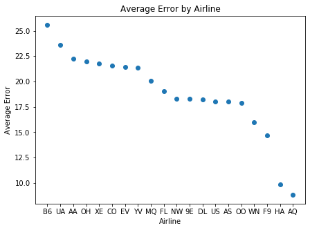

```python
fig, ax = plt.subplots(figsize=(7, 5))
ax.scatter(carrier_arr_err_mean.index, carrier_arr_err_mean)
ax.set_title('Average Error by Airline')
ax.set_xlabel('Airline')
ax.set_ylabel('Average Error')
```

#### Use `df.apply()` method (method 2) to calculate median of error (chose to demonstrate mean and median)

```python
carrier_arr_err_med = carrier_arr_err.groupby('Carrier')['Arrival Error'].median().sort_values(ascending=False)

print(carrier_arr_err_med)
```

```
Carrier
B6    13.0
UA    12.0
US    12.0
9E    11.0
AA    11.0
AS    11.0
OH    11.0
NW    11.0
XE    11.0
EV    11.0
CO    11.0
MQ    10.0
DL    10.0
YV    10.0
OO    10.0
FL    10.0
F9     9.0
WN     9.0
AQ     6.0
HA     6.0
Name: Arrival Error, dtype: float64
```

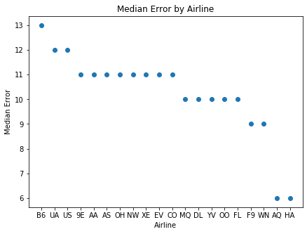

```python
fig, ax = plt.subplots(figsize=(7, 5))
ax.scatter(carrier_arr_err_med.index, carrier_arr_err_med)
ax.set_title('Median Error by Airline')
ax.set_xlabel('Airline')
ax.set_ylabel('Median Error')
```

## Question 7 (1 of 4 additional explorations)

### Plot of departure and arrival densities by latitude and longitude (constrained to United States)

#### Attain flights with departure or arrival in US

```python
iata2country = dict(zip(df_codes.iata, df_codes.country))

def rg_country_rowwise(row):
    if iata2country[row['Origin']] == 'USA' or iata2country[row['Dest']] == 'USA':
        country = 'USA'
    else:
        country = 'Outside USA'

    return country


def rg_coord_dep(row):
    return iata2geo[row['Origin']]


def rg_coord_arr(row):
    return iata2geo[row['Dest']]


start_time = timeit.default_timer()

flights_country_series = df_flights.apply(rg_country_rowwise, axis=1)

flights_dep_coord_series = df_flights.apply(rg_coord_dep, axis=1)

flights_arr_coord_series = df_flights.apply(rg_coord_arr, axis=1)

flights_geo = pd.DataFrame({'Country':flights_country_series.values, 'Dep Coord':flights_dep_coord_series.values, 'Arr Coord':flights_arr_coord_series.values, 'Arr Delay':df_flights['ArrDelay'], 'Dep Delay':df_flights['DepDelay']})

flights_geo = flights_geo.loc[flights_geo['Country'] == 'USA']  # include only flights with USA departure and/or arrival

# print(flights_geo)
# print()
# print()

duration = timeit.default_timer() - start_time

print('Completed in {:.2f} min.'.format(duration/60))
```

```
Completed in 4.24 min.
```

```python
dep_geos = flights_geo.groupby(['Dep Coord']).count().reset_index()
dep_lats = [y[0] for y in dep_geos['Dep Coord']]
dep_longs = [y[1] for y in dep_geos['Dep Coord']]
dep_counts = dep_geos['Country']  # count of flights classified in USA
```

```python
arr_geos = flights_geo.groupby(['Arr Coord']).count().reset_index()
arr_lats = [y[0] for y in arr_geos['Arr Coord']]
arr_longs = [y[1] for y in arr_geos['Arr Coord']]
arr_counts = arr_geos['Country']  # count of flights classified in USA
```

This plot shows the departure densities reporesented by the blue shaded circles as well as the arrival densities represented by the green unfilled circles. Feel free to zoom, pan, and click on the markers to view the airport code.

```python
m = folium.Map(location=[39.8283, -98.5795], zoom_start=4)  # center of United States and start zoom to include entire country

# add departure count circle markers
max_dep_count = max(dep_counts)
for dep_lat, dep_long, dep_val in zip(dep_lats, dep_longs, dep_counts):
    folium.CircleMarker(
        location=[dep_lat, dep_long],
        radius=dep_val / max_dep_count * 50,  # scale radius of marker linearly with num of flights
        popup=list(iata2geo.keys())[list(iata2geo.values()).index((dep_lat, dep_long))],  # allow click to show name of airport
        color='#3186cc',
        fill=True,
        fill_color='#3186cc',

        opacity = 0.9,
        weight = 3,
    ).add_to(m)

# add departure count circle markers
max_arr_count = max(arr_counts)
for arr_lat, arr_long, arr_val in zip(arr_lats, arr_longs, arr_counts):
    folium.CircleMarker(
        location=[arr_lat, arr_long],
        radius=arr_val / max_arr_count * 50,  # scale radius of marker linearly with num of flights
        popup=list(iata2geo.keys())[list(iata2geo.values()).index((arr_lat, arr_long))],  # allow click to show name of airport
        color='#11a30f',
        opacity = 0.5,
        weight = 8,
    ).add_to(m)


m
```

[interactive chart not shown]

The departure and arrival densities (blue vs green circles) do not differ significantly for any given airport so might be better to visualize the sum of departures and arrivals for total traffic as a heat map.

#### Combined departures and arrivals heatmap plot

```python
dep_and_arr_counts = [sum(x) for x in zip(dep_counts, arr_counts)]  # total traffic value list for heatmap with undifferentiated traffic
```

```python
m2 = folium.Map(location=[39.8283, -98.5795], zoom_start=4)  # center of United States and start zoom to include entire country
hm = HeatMap(list(zip(dep_lats, dep_longs, dep_and_arr_counts)), min_opacity=0.2, max_val=max(dep_and_arr_counts), radius=30, blur=15, max_zoom=1).add_to(m2)
m2
```

[interactive chart not shown]

## Question 8 (2 of 4 additional explorations)

### Plot of departure and arrival *delay* densities by latitude and longitude (constrained to United States)

#### Plotting total sum of delays for each coordinate, broken into departure delay and arrival buckets.

```python
dep_delays = flights_geo.groupby(['Dep Coord']).sum().reset_index()['Dep Delay']
arr_delays = flights_geo.groupby(['Arr Coord']).sum().reset_index()['Arr Delay']
```

```python
m = folium.Map(location=[39.8283, -98.5795], zoom_start=4)  # center of United States and start zoom to include entire country

# add departure count circle markers
max_dep_delay = max(dep_delays)
for dep_lat, dep_long, dep_val in zip(dep_lats, dep_longs, dep_delays):
    folium.CircleMarker(
        location=[dep_lat, dep_long],
        radius=dep_val / max_dep_delay * 70,  # scale radius of marker linearly with num of flights
        popup=list(iata2geo.keys())[list(iata2geo.values()).index((dep_lat, dep_long))],  # allow click to show name of airport
        color='#3186cc',
        fill=True,
        fill_color='#3186cc',

        opacity = 0.9,
        weight = 3,
    ).add_to(m)

m
```

[interactive chart not shown]

#### Summing all delays disadvantages airports with larger flight volumes so average delay may be more reflective of delay per flights.

```python
dep_delays = flights_geo.groupby(['Dep Coord']).mean().reset_index()['Dep Delay']
arr_delays = flights_geo.groupby(['Arr Coord']).mean().reset_index()['Arr Delay']
```

```python
m = folium.Map(location=[39.8283, -98.5795], zoom_start=4)  # center of United States and start zoom to include entire country

# add departure delay sum circle markers
max_dep_delay = max(dep_delays)
for dep_lat, dep_long, dep_val in zip(dep_lats, dep_longs, dep_delays):
    folium.CircleMarker(
        location=[dep_lat, dep_long],
        radius=dep_val / max_dep_delay * 50,  # scale radius of marker linearly with num of flights
        popup=list(iata2geo.keys())[list(iata2geo.values()).index((dep_lat, dep_long))],  # allow click to show name of airport
        color='#3186cc',
        fill=True,
        fill_color='#3186cc',

        opacity = 0.9,
        weight = 3,
    ).add_to(m)

m
```

[interactive chart not shown]

```python
m = folium.Map(location=[39.8283, -98.5795], zoom_start=4)  # center of United States and start zoom to include entire country

# add arrival sum circle markers
max_arr_delay = max(arr_delays)
for arr_lat, arr_long, dep_val in zip(arr_lats, arr_longs, arr_delays):
    folium.CircleMarker(
        location=[arr_lat, arr_long],
        radius=dep_val / max_arr_delay * 50,  # scale radius of marker linearly with num of flights
        popup=list(iata2geo.keys())[list(iata2geo.values()).index((arr_lat, arr_long))],  # allow click to show name of airport
        color='#11a30f',
        fill=True,
        fill_color='#11a30f',

        opacity = 0.9,
        weight = 3,
    ).add_to(m)

m
```

[interactive chart not shown]

## Question 9 (3 of 4 additional explorations)

### Histograms of delays per airline given 15 minute window for delayed classification

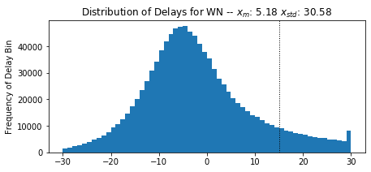

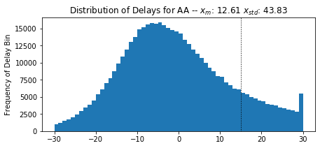

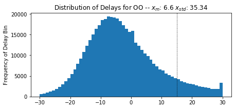

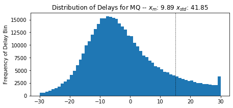

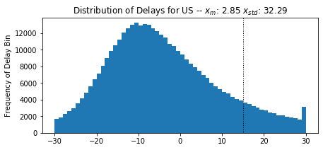

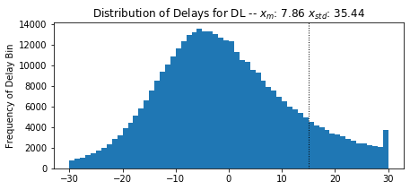

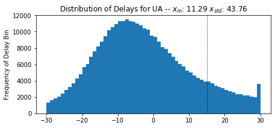

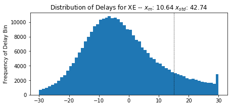

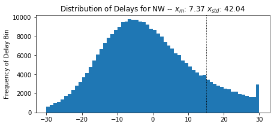

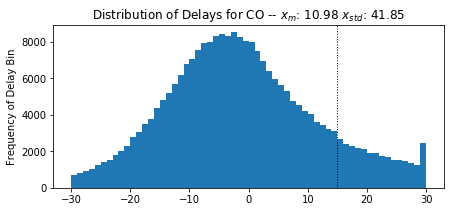

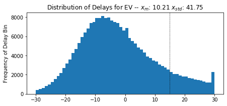

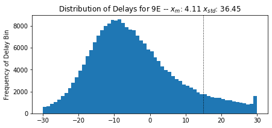

[8 more figures not shown]

```python
airline_delays = pd.DataFrame({'Carrier': df_flights['UniqueCarrier'], 'ArrDelay': df_flights['ArrDelay']})


for carrier in top_carriers:

    data = airline_delays.loc[airline_delays['Carrier'] == carrier]['ArrDelay']

    fig, ax = plt.subplots(figsize=(7, 3))
    ax.hist(data, bins=np.arange(-30, 31))
    ax.set_title('Distribution of Delays for ' + str(carrier) + ' -- $x_m$: ' + str(round(data.mean(), 2)) + ' $x_{std}$: ' + str(round(data.std(), 2)))
    ax.set_ylabel('Arrival Delay (min)')
    ax.set_ylabel('Frequency of Delay Bin')
    ax.axvline(15, color='black', lw=1, ls=':')
```

The plots above show the distributions of delays for each airline along with the mean. For this analysis, flights with delays longer than 15 minutes are considered not on-time. When assesing an airline with regard to whether the airline is pushing up against the 15-minute classification, there are several attributes one might consider:

- Average delay. If the average delay is more positive, this might indicate an airline allows their flights to arrive slightly after the scheduled time.
- Std and average of delay. If the average delay is more positive and the standard deviation is small, this suggests an airline can control their flight time but chooses overly-optimistic scheduled arrival times.
- Shape of the histogram around the `delay = +15 min` mark. If there is a relatively sharp dropoff in the requency of flights with delays > +15 min compared to flights with delays < +15 min, that airline may have flights rushing to get in before the 15 minute delay mark.

## Question 10 (4 of 4 additional explorations)

### Identification of Airline Hubs

#### Counting number of departures and arrivals from each airport by each airline

```python
airline_airports = pd.concat([pd.DataFrame({'Carrier':df_flights['UniqueCarrier'], 'Airport':df_flights['Origin']}), pd.DataFrame({'Carrier':df_flights['UniqueCarrier'], 'Airport':df_flights['Dest']})])

airline_airports = pd.DataFrame(airline_airports.groupby(['Carrier', 'Airport']).size()).sort_values(by=['Carrier', 0]).reset_index()

# airline_airports
```

```python
# airline_airports.loc[airline_airports['Carrier'] == 'AA'][-5:][::-1]  # uncomment for test to check counts
```

```python
print('The most likely five candidates for the hub airports of different airlines are given below based on the flight data of the given year.')

for airline in top_carriers:
    hub_airports = airline_airports.loc[airline_airports['Carrier'] == airline]['Airport'].to_list()[-5:][::-1]
    print('\t{} -- {}'.format(airline, hub_airports))
```

```
The most likely five candidates for the hub airports of different airlines are given below based on the flight data of the given year.
	WN -- ['LAS', 'MDW', 'PHX', 'BWI', 'HOU']
	AA -- ['DFW', 'ORD', 'MIA', 'LAX', 'LGA']
	OO -- ['SLC', 'DEN', 'ORD', 'LAX', 'SFO']
	MQ -- ['DFW', 'ORD', 'LGA', 'LAX', 'RDU']
	US -- ['CLT', 'PHX', 'PHL', 'LAS', 'DCA']
	DL -- ['ATL', 'SLC', 'LGA', 'CVG', 'JFK']
	UA -- ['ORD', 'DEN', 'SFO', 'LAX', 'IAD']
	XE -- ['IAH', 'EWR', 'CLE', 'LAX', 'MCI']
	NW -- ['MSP', 'DTW', 'MEM', 'ORD', 'IND']
	CO -- ['IAH', 'EWR', 'CLE', 'LAX', 'MCO']
	EV -- ['ATL', 'CVG', 'CAE', 'PFN', 'BTR']
	9E -- ['DTW', 'MEM', 'MSP', 'ATL', 'IND']
	FL -- ['ATL', 'MCO', 'BWI', 'TPA', 'BOS']
	YV -- ['PHX', 'ORD', 'IAD', 'CLT', 'DEN']
	OH -- ['CVG', 'JFK', 'LGA', 'BOS', 'ATL']
	B6 -- ['JFK', 'BOS', 'MCO', 'FLL', 'LGB']
	AS -- ['SEA', 'ANC', 'PDX', 'LAX', 'SFO']
	F9 -- ['DEN', 'LAS', 'SLC', 'LAX', 'SAN']
	HA -- ['HNL', 'OGG', 'LIH', 'KOA', 'ITO']
	AQ -- ['HNL', 'OGG', 'LIH', 'KOA', 'ITO']
```

```python
duration_tot = timeit.default_timer() - start_time_tot

print('Total exam notebook completed in {:.2f} min.'.format(duration_tot/60))
```

```
Total exam notebook completed in 20.59 min.
```